# Final Project for BIOS 26211

Author

Alissa Domenig, Romy Li, and Cameron Lozano

## 1 Background

(Written by Alissa.)

The aim of our project was to explore the relationship between nutrition and disease to better understand how dietary factors influence health outcomes. By examining whether nutritional data can be used to predict disease status, we wanted to identify potential applications for improving public health and developing preventative strategies. To achieve this, we compared the performance of various classification models in predicting health conditions based on dietary intake data.

More specifically, we used data to answer these two questions:

1. Can we reliably predict diagnosis of the outcome conditions from mean daily nutrient intake?
2. Which classification models predict with the best performance?

We used a Naïve Bayes classifier, a Tree and Random Tree model, and then finally, a Neural Network model to answer these questions.

While all relevant code for this project is included in this report, please note that the individual R and Python files can also be found at https://github.com/c-lozano/ML_final.

## 2 The Data

(Written by Alissa and Cameron.)

The data used for this project (National Center for Health Statistics, 2021-2023) is from the National Health and Nutrition Examination Survey (NHANES), which is a long-running program conducted by the CDC. NHANES is designed to assess the health and nutritional status of adults and children in the United States. This survey has been conducted in various forms since the early 1960s and is now an ongoing program with continuous data collection, but we decided to just take the dataset from 2021-2023.

Participants are selected using a complex probability sampling method to ensure that the results are representative of the U.S. population. NHANES has five different sections in total: demographic data, dietary data, examination data, laboratory data, and questionnairee data. For our project, we only used the dietary data and the “Medical Conditions” subset of the questionnaire data. The dietary data consists of records of every food and liquid consumed by each participant over the course of two discrete days as well as each participant’s total intake of food energy (in kcal) and 42 nutrients (in grams, milligrams, or micrograms) as calculated from the consumption records using USDA’s Food and Nutrient Database for Dietary Studies August 2021-August 2023 (FNDDS 2021- 2023). The medical conditions questionnaire data consists of a list of participant responses (“Yes”, “No”, “Refused”, “Don’t know”, or “Missing) to questions asked by trained interviewers regarding the participants’ histories of being diagnosed with a variety of conditions (such as asthma, heart attacks, and cancer). For example, one feature of the data consists of participant responses to the question, “Has a doctor or other health professional ever told you that you have asthma?” These two datasets are loaded below, and a sample glimpse of each dataset are provided in Listing 1 and Listing 2 respectively (located in the Appendix, Section 7, in the interest of saving space).

```r
Nutrition_D1 <- read_xpt('https://wwwn.cdc.gov/Nchs/Data/Nhanes/Public/2021/DataFiles/DR1TOT_L.xpt')
Nutrition_D2 <- read_xpt('https://wwwn.cdc.gov/Nchs/Data/Nhanes/Public/2021/DataFiles/DR2TOT_L.xpt')
Medical_Conditions <- read_xpt('https://wwwn.cdc.gov/Nchs/Data/Nhanes/Public/2021/DataFiles/MCQ_L.xpt')
```

We chose the eight most frequently occurring conditions as our response variables: asthma, hay fever, arthritis, congestive heart failure, coronary heart disease, heart attacks, thyroid problems, and cancer. For our predictor variables, we kept all the variables that summarized the total dietary intake of the individuals within one day, which encompasses broad categories like total fats, carbohydrates, and fiber, as well as more specific nutrients such as vitamin B-12, caffeine, and magnesium.

To clean the data, we selected all the relevant columns from the dietary data and the questionnaire data, removed all the NA values, and then used the participant sequence number to match the people across the datasets. For some of our models, it was more convenient use separate subsets of the data, each containing all observations of the predictor variables and one of the outcome variables, than to use the whole data containing every outcome variable, so we split the data accordingly and packaged the subsets (each corresponding to one outcome variable) into a list. The code for performing these transformations is reproduced below:

```r
# DataCleaning.R

# Setup ####

library(haven)
library(dplyr)
library(stringr)
library(sjlabelled)
library(tidyr)
library(janitor)

overwriteXPT <- F # change to TRUE to overwrite existing merged data file

# Loading data ####

Nutrition_D1 <- read_xpt('https://wwwn.cdc.gov/Nchs/Data/Nhanes/Public/2021/DataFiles/DR1TOT_L.xpt')
Nutrition_D2 <- read_xpt('https://wwwn.cdc.gov/Nchs/Data/Nhanes/Public/2021/DataFiles/DR2TOT_L.xpt')
Medical_Conditions <- read_xpt('https://wwwn.cdc.gov/Nchs/Data/Nhanes/Public/2021/DataFiles/MCQ_L.xpt')


# Cleaning and merging ####

#Keeping SEQN and columns Energy - Caffeine
Filtered_Nutrition_D1 <- Nutrition_D1 %>% select(SEQN, 33:75)
Filtered_Nutrition_D2 <- Nutrition_D2 %>% select(SEQN, 16:58)

#Rename the columns
colnames(Filtered_Nutrition_D1)[-1] <- get_label(Filtered_Nutrition_D1)[-1]
colnames(Filtered_Nutrition_D2)[-1] <- get_label(Filtered_Nutrition_D2)[-1]

#Remove brackets
colnames(Filtered_Nutrition_D1) <- gsub("\\s*\\(.*?\\)", "", colnames(Filtered_Nutrition_D1))
colnames(Filtered_Nutrition_D2) <- gsub("\\s*\\(.*?\\)", "", colnames(Filtered_Nutrition_D2))

#Combine the datasets by averaging them
Filtered_Nutrition_Avg <- Filtered_Nutrition_D1 %>%
  mutate(across(2:ncol(.), ~ (Filtered_Nutrition_D1[[cur_column()]] + Filtered_Nutrition_D2[[cur_column()]]) / 2))

#Remove NA values
Filtered_Nutrition_Avg_Cleaned <- na.omit(Filtered_Nutrition_Avg)
na_rows_removed <- nrow(Filtered_Nutrition_Avg) - nrow(Filtered_Nutrition_Avg_Cleaned)

#Select the columns we want and rename them
Filtered_Medical_Conditions <- Medical_Conditions %>%
  select(
    SEQN, MCQ010, AGQ030, MCQ160A, MCQ160B, MCQ160C, MCQ160E, MCQ160M, MCQ220
  ) %>%
  rename(
    Asthma = MCQ010,
    Hay_Fever = AGQ030,
    Arthritis = MCQ160A,
    Congestive_Heart_Failure = MCQ160B,
    Coronary_Heart_Disease = MCQ160C,
    Heart_Attack = MCQ160E,
    Thyroid_Problems = MCQ160M,
    Cancer = MCQ220
  )

# Replace all NA values with 0 in both datasets
Filtered_Medical_Conditions[is.na(Filtered_Medical_Conditions)] <- 0

# Merge both datasets by SEQN, keeping only matching samples
Merged_Data <- inner_join(Filtered_Nutrition_Avg_Cleaned, Filtered_Medical_Conditions, by = "SEQN")


# Write to file ####

# write to XPT (have to remove spaces in names and shorten a couple first)
if (overwriteXPT){
write_xpt(clean_names(Merged_Data,replace=c(unsaturated='unsat'))
          ,path='Merged_Data.xpt')
}
```

```r
# DataSplit.R

# Setup ####

library(haven)
library(dplyr)

# Split merged data into separate sets for each outcome variable

nutr <- read_xpt('Merged_Data.xpt')

nutr <- nutr |>
  mutate(across(45:52, ~factor(.x,
                               levels=c(1,2),
                               labels=c('Yes','No'))))

nutrFilt <- list()

nutrNames <- names(nutr)

for (j in 45:52){
  nutrFilt[[j-44]] <- nutr |>
    dplyr::select(!(45:52), j)
}

names(nutrFilt) <- names(nutr)[45:52]

nutrFilt$asthma <- nutrFilt$asthma |>
  filter(asthma %in% c('Yes','No'))

nutrFilt$hay_fever <- nutrFilt$hay_fever |>
  filter(hay_fever %in% c('Yes','No'))

nutrFilt$arthritis <- nutrFilt$arthritis |>
  filter(arthritis %in% c('Yes','No'))

nutrFilt$congestive_heart_failure <- nutrFilt$congestive_heart_failure |>
  filter(congestive_heart_failure %in% c('Yes','No'))

nutrFilt$coronary_heart_disease <- nutrFilt$coronary_heart_disease |>
  filter(coronary_heart_disease %in% c('Yes','No'))

nutrFilt$heart_attack <- nutrFilt$heart_attack |>
  filter(heart_attack %in% c('Yes','No'))

nutrFilt$thyroid_problems <- nutrFilt$thyroid_problems |>
  filter(thyroid_problems %in% c('Yes','No'))

nutrFilt$cancer <- nutrFilt$cancer |>
  filter(cancer %in% c('Yes','No'))
```

## 3 Methods

(Written by Cameron.)

To assess whether the binary NHANES condition diagnosis outcomes could be predicted from the numerical 2-day average nutrient intakes, we utilized three types of models: Bayes classifiers, decision tree and random forest, and neural network. Each of these model types was trained to predict, separately, each of the 8 diagnosis outcomes from all 43 of the energy/nutrient intake predictors. In order to train the model only using the “Yes” and “No” outcome values (i.e., not the “Refused to answer”, “Don’t know”, etc. answers), we filtered the data to contain only observations with these values *after* first splitting the data into separate subsets for each outcome variable. Because of this, each data subset used to train the models had a different number of remaining observations, though all subsets had more than 4000 observations. The distribution of values for each outcome variable after this filtering are provided in Table 1.

Table 1: Description of outcome values. Each row represents one filtered data subset used to train models to predict one condition diagnosis. The outcome condition name, the total number of “Yes” (Diagnosed) responses, the total number of “No” (Not Diagnosed) responses, and the sum of total responses after filtering are provided.

| Condition | Yes | No | Total |
| --- | --- | --- | --- |
| asthma | 1007 | 4768 | 5775 |
| hay_fever | 1096 | 4683 | 5779 |
| arthritis | 1584 | 2691 | 4275 |
| congestive_heart_failure | 176 | 4104 | 4280 |
| coronary_heart_disease | 236 | 4032 | 4268 |
| heart_attack | 177 | 4101 | 4278 |
| thyroid_problems | 642 | 3640 | 4282 |
| cancer | 730 | 3550 | 4280 |

### 3.1 Bayes classifiers – Cameron

Three Bayes classification methods – naive Bayes, linear discriminant analysis (LDA), and quadratic discriminant analysis (QDA) were used to train a model to predict the diagnosis outcomes (“Yes/Diagnosed” or “No/Not Diagnosed”) for each condition (separately) from the set of 43 nutrient predictor variables. Prediction accuracies and receiver operator characterisitic (ROC) curves were extracted from each model trained under 10-fold cross-validation to assess performance.

The code for training these models is reproduced below:

```r
# Setup ####

library(tidyverse)
library(tidymodels)
library(discrim)
library(knitr)

plotsToWindow <- F # change to T to show plots in RStudio
plotsToFile <- T # change to T to overwrite the PNGs in ../figures/


# Data-wrangling ####

setwd(dirname(rstudioapi::getActiveDocumentContext()$path))

source('DataSplit.R')


# Model training ####

resampleAccuracies <- function(model,recs,folds){
  nutrWorks <- list()
  nutrFits <- list()
  nutrAccuracies <- list()

  for (w in 1:length(recs)){

    nutrWorks[[w]] <- workflow() |>
      add_model(model) |>
      add_recipe(recs[[w]])

    nutrFits[[w]] <- fit_resamples(nutrWorks[[w]],
                                   folds[[w]],
                                   metrics=metric_set(accuracy,roc_auc),
                                   control = control_resamples(save_pred=T))

    nutrAccuracies[[w]] <- collect_metrics(nutrFits[[w]]) |>
      dplyr::select(!c(.estimator,.config,n)) |>
      mutate(outcome=names(nutrFilt)[w],.before=1)

  }

  names(nutrAccuracies) <- names(nutrFits) <- names(recs)

  fits <- nutrFits

  accuracies <- bind_rows(nutrAccuracies)

  return(list(accuracies=accuracies,fits=fits))
}


## Outliers included ####

nutrRecs <- list(
  recipe(asthma ~ ., data=nutrFilt$asthma),
  recipe(hay_fever ~ ., data=nutrFilt$hay_fever),
  recipe(arthritis ~ ., data=nutrFilt$arthritis),
  recipe(congestive_heart_failure ~ ., data=nutrFilt$congestive_heart_failure),
  recipe(coronary_heart_disease ~ ., data=nutrFilt$coronary_heart_disease),
  recipe(heart_attack ~ ., data=nutrFilt$heart_attack),
  recipe(thyroid_problems ~ ., data=nutrFilt$thyroid_problems),
  recipe(cancer ~ ., data=nutrFilt$cancer)
)

nutrFolds <- list()

for (w in 1:length(nutrFilt)){
  nutrRecs[[w]] <- nutrRecs[[w]] |>
    update_role(seqn,new_role='ID')

  nutrFolds[[w]] <- vfold_cv(nutrFilt[[w]],v=10)
}

names(nutrRecs) <- names(nutrFolds) <- names(nutrFilt)


### Naive Bayes ####

nbSpec <- naive_Bayes() |>
  set_mode('classification') |>
  set_engine('naivebayes') |>
  set_args(usekernel=F)

resamples <- resampleAccuracies(model=nbSpec,recs=nutrRecs,folds=nutrFolds)

nbFits <- resamples$fits
nbAccuracies <- resamples$accuracies


### Linear discriminant analysis ####

ldaSpec <- discrim_linear() |>
  set_mode('classification') |>
  set_engine('MASS')

resamples <- resampleAccuracies(model=ldaSpec,recs=nutrRecs,folds=nutrFolds)

ldaFits <- resamples$fits
ldaAccuracies <- resamples$accuracies


### Quadratic discriminant analysis ####

qdaSpec <- discrim_quad() |>
  set_mode('classification') |>
  set_engine('MASS')

resamples <- resampleAccuracies(model=qdaSpec,recs=nutrRecs,folds=nutrFolds)

qdaFits <- resamples$fits
qdaAccuracies <- resamples$accuracies


## Outliers removed ####

nutrCropped <- nutr |>
  filter(!if_any(1:44, rstatix::is_outlier))

nutrFilt <- list()

nutrNames <- names(nutrCropped)

for (j in 45:52){
  nutrFilt[[j-44]] <- nutrCropped |>
    dplyr::select(!(45:52), j)
}

names(nutrFilt) <- names(nutrCropped)[45:52]

nutrFilt$asthma <- nutrFilt$asthma |>
  filter(asthma %in% c('Yes','No'))

nutrFilt$hay_fever <- nutrFilt$hay_fever |>
  filter(hay_fever %in% c('Yes','No'))

nutrFilt$arthritis <- nutrFilt$arthritis |>
  filter(arthritis %in% c('Yes','No'))

nutrFilt$congestive_heart_failure <- nutrFilt$congestive_heart_failure |>
  filter(congestive_heart_failure %in% c('Yes','No'))

nutrFilt$coronary_heart_disease <- nutrFilt$coronary_heart_disease |>
  filter(coronary_heart_disease %in% c('Yes','No'))

nutrFilt$heart_attack <- nutrFilt$heart_attack |>
  filter(heart_attack %in% c('Yes','No'))

nutrFilt$thyroid_problems <- nutrFilt$thyroid_problems |>
  filter(thyroid_problems %in% c('Yes','No'))

nutrFilt$cancer <- nutrFilt$cancer |>
  filter(cancer %in% c('Yes','No'))

for (w in 1:length(nutrFilt)){
  nutrFilt[[w]] <- nutrFilt[[w]] |>
    dplyr::select(!where(is.numeric), where(~ is.numeric(.x) && var(.x)!=0))
}

nutrRecs <- list(
  recipe(asthma ~ ., data=nutrFilt$asthma),
  recipe(hay_fever ~ ., data=nutrFilt$hay_fever),
  recipe(arthritis ~ ., data=nutrFilt$arthritis),
  recipe(congestive_heart_failure ~ ., data=nutrFilt$congestive_heart_failure),
  recipe(coronary_heart_disease ~ ., data=nutrFilt$coronary_heart_disease),
  recipe(heart_attack ~ ., data=nutrFilt$heart_attack),
  recipe(thyroid_problems ~ ., data=nutrFilt$thyroid_problems),
  recipe(cancer ~ ., data=nutrFilt$cancer)
)


nutrFolds <- list()

for (w in 1:length(nutrFilt)){
  nutrRecs[[w]] <- nutrRecs[[w]] |>
    update_role(seqn,new_role='ID')

  nutrFolds[[w]] <- vfold_cv(nutrFilt[[w]],v=10)
}

names(nutrRecs) <- names(nutrFolds) <- names(nutrFilt)

### Naive Bayes ####

resamples <- resampleAccuracies(model=nbSpec,recs=nutrRecs,folds=nutrFolds)

nbFits_outliers <- resamples$fits
nbAccuracies_outliers <- resamples$accuracies


### Linear discriminant analysis ####

resamples <- resampleAccuracies(model=ldaSpec,recs=nutrRecs,folds=nutrFolds)

ldaFits_outliers <- resamples$fits
ldaAccuracies_outliers <- resamples$accuracies


### Quadratic discriminant analysis ####

resamples <- resampleAccuracies(model=qdaSpec,recs=nutrRecs,folds=nutrFolds)

qdaFits_outliers <- resamples$fits
qdaAccuracies_outliers <- resamples$accuracies
```

### 3.2 Decision tree and random forest – Romy

Loading the necessary libraries and cleaning the data further for my analysis.

```r
# Loading the necessary libraries and data set.
library(haven)
library(tidyverse)
library(tidymodels)
library(randomForest)
library(rpart.plot)
library(vip)
library(modeldata)
library(ggfortify)
library(ggplot2)
df <- read_xpt("Merged_Data.xpt")
df[45:52] <- lapply(df[45:52], as.factor) # Convert response variables into factors

# Keep only "yes" (1) and "no" (2) and remove "missing" or "don't know" for all responses
asthma <- df[1:45] |> filter(asthma != 9) |> mutate(asthma = droplevels(asthma))
hay_fever <- df[c(1:44,46)] |> filter(hay_fever != 9) |> mutate(hay_fever = droplevels(hay_fever))
arthritis <- df[c(1:44,47)] |> filter(!arthritis %in% c(0,9)) |> mutate(arthritis = droplevels(arthritis))
congestive <- df[c(1:44,48)] |> filter(!congestive_heart_failure %in% c(0,9)) |> mutate(congestive_heart_failure = droplevels(congestive_heart_failure))
coronary <- df[c(1:44,49)] |> filter(!coronary_heart_disease %in% c(0,9)) |> mutate(coronary_heart_disease = droplevels(coronary_heart_disease))
heart_attack <- df[c(1:44,50)] |> filter(!heart_attack %in% c(0,9)) |> mutate(heart_attack = droplevels(heart_attack))
thyroid <- df[c(1:44,51)] |> filter(!thyroid_problems %in% c(0,7,9)) |> mutate(thyroid_problems = droplevels(thyroid_problems))
cancer <- df[c(1:44,52)] |> filter(!cancer %in% c(0,7,9)) |> mutate(cancer = droplevels(cancer))
```

I started with training a decision tree model

```r
# Training a basic decision tree model
class_tree_spec <- decision_tree() |>
  set_engine('rpart') |>
  set_mode("classification")

## Asthma
split <- initial_split(asthma, prop = 1/2)
asthma_train <- training(split)
asthma_test <- testing(split)

asthma_recipe <- recipe(asthma ~ ., data = asthma_train) |>
  update_role('seqn', new_role = 'ID')
asthma_workflow <- workflow() |>
  add_model(class_tree_spec) |>
  add_recipe(asthma_recipe)
class_tree_fit <- asthma_workflow |> fit(asthma_train)
class_tree_fit |> extract_fit_engine() |> rpart.plot(roundint = F, box.palette = "Blues")
asthma_class_pred <- augment(class_tree_fit, new_data = asthma_test)
asthma_train_accuracy <- augment(class_tree_fit, new_data = asthma_train) |> accuracy(truth = asthma, estimate = .pred_class)
asthma_test_accuracy <- asthma_class_pred |> accuracy(truth = asthma, estimate = .pred_class)
asthma_auc <- asthma_class_pred |> roc_auc(truth = asthma, .pred_2)
asthma_class_pred |> conf_mat(truth = asthma, estimate = .pred_class)

## Hay fever
split <- initial_split(hay_fever, prop = 1/2)
hay_fever_train <- training(split)
hay_fever_test <- testing(split)

hay_fever_recipe <- recipe(hay_fever ~ ., data = hay_fever_train) |>
  update_role('seqn', new_role = 'ID')
hay_fever_workflow <- workflow() |>
  add_model(class_tree_spec) |>
  add_recipe(hay_fever_recipe)
class_tree_fit <- hay_fever_workflow |> fit(hay_fever_train)
class_tree_fit |> extract_fit_engine() |> rpart.plot(roundint = F, box.palette = "Greys")
hay_fever_class_pred <- augment(class_tree_fit, new_data = hay_fever_test)
hay_fever_train_accuracy <- augment(class_tree_fit, new_data = hay_fever_train) |> accuracy(truth = hay_fever, estimate = .pred_class)
hay_fever_test_accuracy <- hay_fever_class_pred |> accuracy(truth = hay_fever, estimate = .pred_class)
hay_fever_auc <- hay_fever_class_pred |> roc_auc(truth = hay_fever, .pred_2)
hay_fever_class_pred |> conf_mat(truth = hay_fever, estimate = .pred_class)

## Arthritis
split <- initial_split(arthritis, prop = 1/2)
arthritis_train <- training(split)
arthritis_test <- testing(split)

arthritis_recipe <- recipe(arthritis ~ ., data = arthritis_train) |>
  update_role('seqn', new_role = 'ID')
arthritis_workflow <- workflow() |>
  add_model(class_tree_spec) |>
  add_recipe(arthritis_recipe)
class_tree_fit <- arthritis_workflow |> fit(arthritis_train)
class_tree_fit |> extract_fit_engine() |> rpart.plot(roundint = F, box.palette = "Greys")
arthritis_class_pred <- augment(class_tree_fit, new_data = arthritis_test)
arthritis_train_accuracy <- augment(class_tree_fit, new_data = arthritis_train)|> accuracy(truth = arthritis, estimate = .pred_class)
arthritis_test_accuracy <- arthritis_class_pred |> accuracy(truth = arthritis, estimate = .pred_class)
arthritis_auc <- arthritis_class_pred |> roc_auc(truth = arthritis, .pred_1)
arthritis_class_pred |> conf_mat(truth = arthritis, estimate = .pred_class)

## Congestive Heart Failure
split <- initial_split(congestive, prop = 1/2)
congestive_train <- training(split)
congestive_test <- testing(split)

congestive_recipe <- recipe(congestive_heart_failure ~ ., data = congestive_train) |>
  update_role('seqn', new_role = 'ID')
congestive_workflow <- workflow() |>
  add_model(class_tree_spec) |>
  add_recipe(congestive_recipe)
class_tree_fit <- congestive_workflow |> fit(congestive_train)
class_tree_fit |> extract_fit_engine() |> rpart.plot(roundint = F, box.palette = "Greys")
congestive_class_pred <- augment(class_tree_fit, new_data = congestive_test)
congestive_train_accuracy <- augment(class_tree_fit, new_data = congestive_train)|> accuracy(truth = congestive_heart_failure, estimate = .pred_class)
congestive_test_accuracy <- congestive_class_pred |> accuracy(truth = congestive_heart_failure, estimate = .pred_class)
congestive_auc <- congestive_class_pred |> roc_auc(truth = congestive_heart_failure, .pred_1)
congestive_class_pred |> conf_mat(truth = congestive_heart_failure, estimate = .pred_class)

## Coronary Heart Disease
split <- initial_split(coronary, prop = 1/2)
coronary_train <- training(split)
coronary_test <- testing(split)

coronary_recipe <- recipe(coronary_heart_disease ~ ., data = coronary_train) |>
  update_role('seqn', new_role = 'ID')
coronary_workflow <- workflow() |>
  add_model(class_tree_spec) |>
  add_recipe(coronary_recipe)
class_tree_fit <- coronary_workflow |> fit(coronary_train)
class_tree_fit |> extract_fit_engine() |> rpart.plot(roundint = F, box.palette = "Greys")
coronary_class_pred <- augment(class_tree_fit, new_data = coronary_test)
coronary_train_accuracy <- augment(class_tree_fit, new_data = coronary_train)|> accuracy(truth = coronary_heart_disease, estimate = .pred_class)
coronary_test_accuracy <- coronary_class_pred |> accuracy(truth = coronary_heart_disease, estimate = .pred_class)
coronary_auc <- coronary_class_pred |> roc_auc(truth = coronary_heart_disease, .pred_1)
coronary_class_pred |> conf_mat(truth = coronary_heart_disease, estimate = .pred_class)

## Heart Attack
split <- initial_split(heart_attack, prop = 1/2)
heart_attack_train <- training(split)
heart_attack_test <- testing(split)

heart_attack_recipe <- recipe(heart_attack ~ ., data = heart_attack_train) |>
  update_role('seqn', new_role = 'ID')
heart_attack_workflow <- workflow() |>
  add_model(class_tree_spec) |>
  add_recipe(heart_attack_recipe)
class_tree_fit <- heart_attack_workflow |> fit(heart_attack_train)
class_tree_fit |> extract_fit_engine() |> rpart.plot(roundint = F, box.palette = "Greys")
heart_attack_class_pred <- augment(class_tree_fit, new_data = heart_attack_test)
heart_attack_train_accuracy <- augment(class_tree_fit, new_data = heart_attack_train)|> accuracy(truth = heart_attack, estimate = .pred_class)
heart_attack_test_accuracy <- heart_attack_class_pred |> accuracy(truth = heart_attack, estimate = .pred_class)
heart_attack_auc <- heart_attack_class_pred |> roc_auc(truth = heart_attack, .pred_1)
heart_attack_class_pred |> conf_mat(truth = heart_attack, estimate = .pred_class)

## Thyroid
split <- initial_split(thyroid, prop = 1/2)
thyroid_train <- training(split)
thyroid_test <- testing(split)

thyroid_recipe <- recipe(thyroid_problems ~ ., data = thyroid_train) |>
  update_role('seqn', new_role = 'ID')
thyroid_workflow <- workflow() |>
  add_model(class_tree_spec) |>
  add_recipe(thyroid_recipe)
class_tree_fit <- thyroid_workflow |> fit(thyroid_train)
class_tree_fit |> extract_fit_engine() |> rpart.plot(roundint = F, box.palette = "Greys")
thyroid_class_pred <- augment(class_tree_fit, new_data = thyroid_test)
thyroid_train_accuracy <- augment(class_tree_fit, new_data = thyroid_train)|> accuracy(truth = thyroid_problems, estimate = .pred_class)
thyroid_test_accuracy <- thyroid_class_pred |> accuracy(truth = thyroid_problems, estimate = .pred_class)
thyroid_auc <- thyroid_class_pred |> roc_auc(truth = thyroid_problems, .pred_1)
thyroid_class_pred |> conf_mat(truth = thyroid_problems, estimate = .pred_class)

## Cancer
split <- initial_split(cancer, prop = 1/2)
cancer_train <- training(split)
cancer_test <- testing(split)

cancer_recipe <- recipe(cancer ~ ., data = cancer_train) |>
  update_role('seqn', new_role = 'ID')
cancer_workflow <- workflow() |>
  add_model(class_tree_spec) |>
  add_recipe(cancer_recipe)
class_tree_fit <- cancer_workflow |> fit(cancer_train)
class_tree_fit |> extract_fit_engine() |> rpart.plot(roundint = F, box.palette = "Greys")
cancer_class_pred <- augment(class_tree_fit, new_data = cancer_test)
cancer_train_accuracy <- augment(class_tree_fit, new_data = cancer_train)|> accuracy(truth = cancer, estimate = .pred_class)
cancer_test_accuracy <- cancer_class_pred |> accuracy(truth = cancer, estimate = .pred_class)
cancer_auc <- cancer_class_pred |> roc_auc(truth = cancer, .pred_2)
cancer_class_pred |> conf_mat(truth = cancer, estimate = .pred_class)
```

Next, I trained a random forest model to see if it outperforms a single decision tree.

```r
# Train a random forest model
bagging_spec <- rand_forest() |>
  set_engine("randomForest", importance = T) |>
  set_mode("classification")

## Asthma
asthma_workflow <- workflow() |>
  add_model(bagging_spec) |>
  add_recipe(asthma_recipe)

asthma_forest_fit <- asthma_workflow |> fit(asthma_train)
asthma_forest_train_accuracy <- augment(asthma_forest_fit, new_data = asthma_train) |>
  accuracy(truth = asthma, estimate = .pred_class)
asthma_forest_pred <- augment(asthma_forest_fit, new_data = asthma_test)
asthma_forest_test_accuracy <- asthma_class_pred |> accuracy(truth = asthma, estimate = .pred_class)
asthma_forest_auc <- asthma_forest_pred |> roc_auc(truth = asthma, .pred_1)
asthma_class_pred |> conf_mat(truth = asthma, estimate = .pred_class)
vip(asthma_forest_fit)

## Hay Fever
hay_fever_workflow <- workflow() |>
  add_model(bagging_spec) |>
  add_recipe(hay_fever_recipe)

hay_fever_forest_fit <- hay_fever_workflow |> fit(hay_fever_train)
hay_fever_forest_train_accuracy <- augment(hay_fever_forest_fit, new_data = hay_fever_train) |>
  accuracy(truth = hay_fever, estimate = .pred_class)
hay_fever_forest_pred <- augment(hay_fever_forest_fit, new_data = hay_fever_test)
hay_fever_forest_test_accuracy <- hay_fever_class_pred |> accuracy(truth = hay_fever, estimate = .pred_class)
hay_fever_forest_auc <- hay_fever_forest_pred |> roc_auc(truth = hay_fever, .pred_1)
hay_fever_class_pred |> conf_mat(truth = hay_fever, estimate = .pred_class)

## Arthritis
arthritis_workflow <- workflow() |>
  add_model(bagging_spec) |>
  add_recipe(arthritis_recipe)

arthritis_forest_fit <- arthritis_workflow |> fit(arthritis_train)
arthritis_forest_train_accuracy <- augment(arthritis_forest_fit, new_data = arthritis_train) |>
  accuracy(truth = arthritis, estimate = .pred_class)
arthritis_forest_pred <- augment(arthritis_forest_fit, new_data = arthritis_test)
arthritis_forest_test_accuracy <- arthritis_class_pred |> accuracy(truth = arthritis, estimate = .pred_class)
arthritis_forest_auc <- arthritis_forest_pred |> roc_auc(truth = arthritis, .pred_1)
arthritis_class_pred |> conf_mat(truth = arthritis, estimate = .pred_class)

## Congestive Heart Failure
congestive_workflow <- workflow() |>
  add_model(bagging_spec) |>
  add_recipe(congestive_recipe)

congestive_forest_fit <- congestive_workflow |> fit(congestive_train)
congestive_forest_train_accuracy <- augment(congestive_forest_fit, new_data = congestive_train) |>
  accuracy(truth = congestive_heart_failure, estimate = .pred_class)
congestive_forest_pred <- augment(congestive_forest_fit, new_data = congestive_test)
congestive_forest_test_accuracy <- congestive_class_pred |> accuracy(truth = congestive_heart_failure, estimate = .pred_class)
congestive_forest_auc <- congestive_forest_pred |> roc_auc(truth = congestive_heart_failure, .pred_1)
congestive_class_pred |> conf_mat(truth = congestive_heart_failure, estimate = .pred_class)

## Coronary Heart Disease
coronary_workflow <- workflow() |>
  add_model(bagging_spec) |>
  add_recipe(coronary_recipe)

coronary_forest_fit <- coronary_workflow |> fit(coronary_train)
coronary_forest_train_accuracy <- augment(coronary_forest_fit, new_data = coronary_train) |>
  accuracy(truth = coronary_heart_disease, estimate = .pred_class)
coronary_forest_pred <- augment(coronary_forest_fit, new_data = coronary_test)
coronary_forest_test_accuracy <- coronary_class_pred |> accuracy(truth = coronary_heart_disease, estimate = .pred_class)
coronary_forest_auc <- coronary_forest_pred |> roc_auc(truth = coronary_heart_disease, .pred_1)
coronary_class_pred |> conf_mat(truth = coronary_heart_disease, estimate = .pred_class)

## Heart Attack
heart_attack_workflow <- workflow() |>
  add_model(bagging_spec) |>
  add_recipe(heart_attack_recipe)

heart_attack_forest_fit <- heart_attack_workflow |> fit(heart_attack_train)
heart_attack_forest_train_accuracy <- augment(heart_attack_forest_fit, new_data = heart_attack_train) |>
  accuracy(truth = heart_attack, estimate = .pred_class)
heart_attack_forest_pred <- augment(heart_attack_forest_fit, new_data = heart_attack_test)
heart_attack_forest_test_accuracy <- heart_attack_class_pred |> accuracy(truth = heart_attack, estimate = .pred_class)
heart_attack_forest_auc <- heart_attack_forest_pred |> roc_auc(truth = heart_attack, .pred_1)
heart_attack_class_pred |> conf_mat(truth = heart_attack, estimate = .pred_class)

## Thyroid
thyroid_workflow <- workflow() |>
  add_model(bagging_spec) |>
  add_recipe(thyroid_recipe)

thyroid_forest_fit <- thyroid_workflow |> fit(thyroid_train)
thyroid_forest_train_accuracy <- augment(thyroid_forest_fit, new_data = thyroid_train) |>
  accuracy(truth = thyroid_problems, estimate = .pred_class)
thyroid_forest_pred <- augment(thyroid_forest_fit, new_data = thyroid_test)
thyroid_forest_test_accuracy <- thyroid_class_pred |> accuracy(truth = thyroid_problems, estimate = .pred_class)
thyroid_forest_auc <- thyroid_forest_pred |> roc_auc(truth = thyroid_problems, .pred_1)
thyroid_class_pred |> conf_mat(truth = thyroid_problems, estimate = .pred_class)

## Cancer
cancer_workflow <- workflow() |>
  add_model(bagging_spec) |>
  add_recipe(cancer_recipe)

cancer_forest_fit <- cancer_workflow |> fit(cancer_train)
cancer_forest_train_accuracy <- augment(cancer_forest_fit, new_data = cancer_train) |>
  accuracy(truth = cancer, estimate = .pred_class)
cancer_forest_pred <- augment(cancer_forest_fit, new_data = cancer_test)
cancer_forest_test_accuracy <- cancer_class_pred |> accuracy(truth = cancer, estimate = .pred_class)
cancer_forest_auc <- cancer_forest_pred |> roc_auc(truth = cancer, .pred_1)
cancer_class_pred |> conf_mat(truth = cancer, estimate = .pred_class)
```

Finally, I did hyperparameter tuning on the random forest model, trying to find the best value of `mtry` that produces the higher AUC value.

```r
## Tuning
set.seed(123)
cv_folds <- vfold_cv(arthritis_train, v = 10)

rf_model <- rand_forest(mtry = tune()) |>
  set_engine("randomForest", importance = TRUE) |>
  set_mode("classification")

rf_recipe <- recipe(arthritis ~ ., data = arthritis_train)

rf_workflow <- workflow() |>
  add_model(rf_model) |>
  add_recipe(rf_recipe)

rf_grid <- grid_regular(
  mtry(range = c(1, 43)),
  levels = 43
)

rf_results <- tune_grid(
  rf_workflow,
  resamples = cv_folds,
  grid = rf_grid,
  metrics = metric_set(roc_auc)
)

tuning_metrics <- rf_results |>
  collect_metrics() |>
  arrange(desc(mean))
tuning_metrics$mtry <- factor(tuning_metrics$mtry, levels = tuning_metrics$mtry)

best_mtry <- rf_results |> select_best(metric = "roc_auc")

final_rf_workflow <- finalize_workflow(rf_workflow, best_mtry)

final_rf_model <- fit(final_rf_workflow, data = arthritis_train)

final_rf_fit <- extract_fit_parsnip(final_rf_model)

arthritis_class_pred <- augment(final_rf_model, new_data = arthritis_test)
arthritis_class_pred |> accuracy(truth = arthritis, estimate = .pred_class)
arthritis_class_pred |> roc_auc(truth = arthritis, .pred_1)
arthritis_class_pred |> conf_mat(truth = arthritis, estimate = .pred_class)
vip(final_rf_fit)
```

### 3.3 Neural network – Alissa

I ran my code in python, since I have worked with their Neural Network packages before and I felt more comfortable using those. However, I can’t find a way to run the code properly in RStudio, so I think if you wanted to run this code, you might need to run it on a python interpreter instead. Either way, I included the plots I got in my results section.

```python
import pandas as pd
import torch
import torch.nn as nn
import torch.optim as optim
from torch.utils.data import DataLoader, TensorDataset
import matplotlib.pyplot as plt
import seaborn as sns
from sklearn.model_selection import KFold
from sklearn.preprocessing import StandardScaler
from sklearn.metrics import accuracy_score, roc_auc_score, confusion_matrix, roc_curve, auc
import numpy as np

# LOAD DATA
path = "/Users/alissadomenig/repositories/ML_final/Merged_Data.csv"
data = pd.read_csv(path)
X = data.iloc[:, :44].values
Y = data.iloc[:, 44:].values
scaler = StandardScaler()
X = scaler.fit_transform(X)
device = torch.device("cuda" if torch.cuda.is_available() else "cpu")

# BUILDING THE NEURAL NETWORK
class SimpleNN(nn.Module):
    def __init__(self, input_size):
        super(SimpleNN, self).__init__()
        self.fc1 = nn.Linear(input_size, 64)
        self.relu = nn.ReLU()
        self.fc2 = nn.Linear(64, 32)
        self.fc3 = nn.Linear(32, 1)
        self.sigmoid = nn.Sigmoid()
        self.dropout = nn.Dropout(0.1) # Using Dropout Layer to prevet overfitting

    def forward(self, x):
        x = self.relu(self.fc1(x))
        x = self.dropout(x)
        x = self.relu(self.fc2(x))
        x = self.dropout(x)
        x = self.fc3(x)
        x = self.sigmoid(x)
        return x

response_variable_names = data.columns[44:]

# SETTING UP CROSS VALIDATION
kf = KFold(n_splits=10, shuffle=True, random_state=42)

epochs = 50
patience = 5

average_train_acc = {}
average_test_acc = {}
train_conf_matrices = {}
test_conf_matrices = {}
auc_scores = {}
roc_curves = {}

for i, response_name in enumerate(response_variable_names):
    y = Y[:, i].reshape(-1, 1)

    # CLEANING THE DATA SO WE ONLY KEEP YES = 1 AND NO = 0
    valid_indices = ((y == 1) | (y == 2)).flatten()
    X_valid = X[valid_indices]
    y_valid = y[valid_indices]
    y_valid = (y_valid == 1).astype(int)

    fold_auc_scores = []
    fold_fprs = []
    fold_tprs = []
    train_acc_scores = []
    test_acc_scores = []
    train_conf_matrices[response_name] = []
    test_conf_matrices[response_name] = []

    ### TRAINING THE MODEL
    for fold, (train_idx, test_idx) in enumerate(kf.split(X_valid)):
        X_train, X_test = X_valid[train_idx], X_valid[test_idx]
        y_train, y_test = y_valid[train_idx], y_valid[test_idx]

        ##class_1_indices = np.where(y_train == 1)[0]
        ##class_0_indices = np.where(y_train == 0)[0]

        ##if len(class_1_indices) < len(class_0_indices):
        ##   sampled_class_0_indices = np.random.choice(class_0_indices, size=len     (class_1_indices), replace=False)
        ##else:
        ##    sampled_class_0_indices = class_0_indices

        ##balanced_train_indices = np.concatenate([class_1_indices, sampled_class_0_indices])
        ##X_train = X_train[balanced_train_indices]
        ##y_train = y_train[balanced_train_indices]

        # CONVERTING TO TENSORS
        X_train_tensor = torch.tensor(X_train, dtype=torch.float32).to(device)
        y_train_tensor = torch.tensor(y_train, dtype=torch.float32).to(device)
        X_test_tensor = torch.tensor(X_test, dtype=torch.float32).to(device)
        y_test_tensor = torch.tensor(y_test, dtype=torch.float32).to(device)

        # CREATING DATASET AND DATA LOADER
        train_dataset = TensorDataset(X_train_tensor, y_train_tensor)
        train_loader = DataLoader(train_dataset, batch_size=32, shuffle=True)

        # INITIALIZING MODEL
        model = SimpleNN(input_size=X.shape[1]).to(device)
        criterion = nn.BCELoss()
        optimizer = optim.Adam(model.parameters(), lr=0.0001)
        best_val_loss = float('inf')
        patience_counter = 0
        best_model_state = None

        # TRAINING LOOP
        for epoch in range(epochs):
            model.train()
            batch_losses = []
            for batch_X, batch_y in train_loader:
                optimizer.zero_grad()
                predictions = model(batch_X).squeeze()
                loss = criterion(predictions, batch_y.squeeze())
                loss.backward()
                optimizer.step()
                batch_losses.append(loss.item())

            model.eval()
            with torch.no_grad():
                val_predictions = model(X_test_tensor).squeeze()
                val_loss = criterion(val_predictions, y_test_tensor.squeeze()).item()

            # USING EARLY STOPPING TO PREVENT OVERFITTING
            if val_loss < best_val_loss:
                best_val_loss = val_loss
                patience_counter = 0
                best_model_state = model.state_dict()
            else:
                patience_counter += 1

            if patience_counter >= patience:
                print(f"Early stopping triggered for {response_name} at epoch {epoch+1}")
                break

        if best_model_state:
            model.load_state_dict(best_model_state)

        model.eval()
        with torch.no_grad():
            train_preds = (model(X_train_tensor).cpu().numpy().flatten() > 0.5).astype(int)
            test_preds = (model(X_test_tensor).cpu().numpy().flatten() > 0.5).astype(int)

        train_acc = accuracy_score(y_train, train_preds)
        test_acc = accuracy_score(y_test, test_preds)

        train_acc_scores.append(train_acc)
        test_acc_scores.append(test_acc)

        # COMPUTE CONFUSION MATRICES
        train_conf_matrix = confusion_matrix(y_train, train_preds)
        test_conf_matrix = confusion_matrix(y_test, test_preds)

        train_conf_matrices[response_name].append(train_conf_matrix)
        test_conf_matrices[response_name].append(test_conf_matrix)

        # COMPUTE ROC AND AUC CURVES
        with torch.no_grad():
            y_pred_probs = model(X_test_tensor).cpu().numpy().flatten()
        fpr, tpr, _ = roc_curve(y_test, y_pred_probs)
        roc_auc = auc(fpr, tpr)

        fold_auc_scores.append(roc_auc)
        fold_fprs.append(fpr)
        fold_tprs.append(tpr)

    # STORING AVERAGE TEST AND TRAIN ACCURACIES
    average_train_acc[response_name] = np.mean(train_acc_scores)
    average_test_acc[response_name] = np.mean(test_acc_scores)
    auc_scores[response_name] = fold_auc_scores
    roc_curves[response_name] = (fold_fprs, fold_tprs)
```

## 4 Results

### 4.1 Bayes classifiers – Cameron

While the naive Bayes and QDA models predicted most of the outcome diagnoses with poor mean cross-validated accuracies (with the only models producing accuracies over 75% being the naive Bayes models for predicting asthma, congestive heart failure, and heart attack diagnoses), the LDA classification models predicted with consistently greater accuracy: all diagnosis outcomes except for arthritis were predicted with mean accuracies over 75% (Figure 1). Initially, we considered this to suggest the LDA models were performing somewhat well.

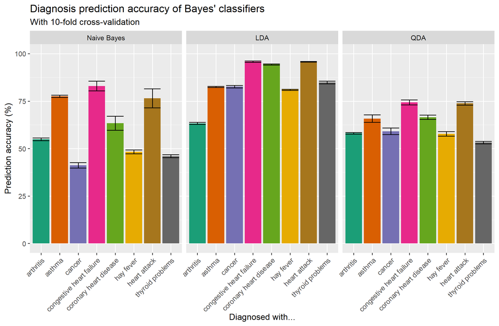

Figure 1: Mean 10-fold cross-validated accuracies for predicting each of the 8 diagnosis outcomes from the 43 nutrient intake predictors, separated by method of Bayes classification (naive Bayes, LDA, or QDA).

Unfortunately, further investigation revealed that all of the models, including the LDAs, were in fact performing only slightly better than would a random classifier predicting solely on the basis of outcome value distribution (i.e., a classifier which, for a diagnosis outcome consisting of 95% “No/Not Diagnosed” values and only 5% “Yes/Diagnosed” values, simply classifies a random 95% of the observations as “No” without regard to predictor values). The expected receiver operator characteristic (ROC) curve for such a random classifier would be linear with a y-intercept of 0 and a slope of 1, and the ROC curves for our models are only marginally different from this (Figure 2; with separated ROCs for the LDA models given in Figure 3). The areas under the ROC curves (ROC-AUCs), which for a random classifier would have an expected value of 0.5, are also only marginally (though significantly, in the case of all of the LDA models) greater than 0.5 (Figure 4).

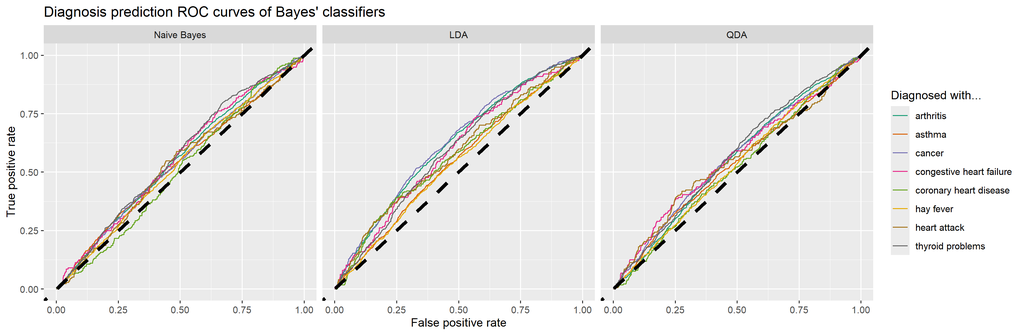

Figure 2: Receiver operator characteristic (ROC) curves for 10-fold cross-validated predictions of diagnosis outcomes from nutrient intake predictors, separated by method of Bayes classification (naive Bayes, LDA, or QDA).

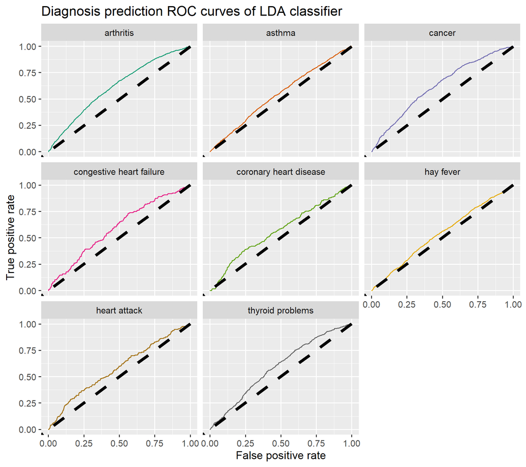

Figure 3: Receiver operator characteristic (ROC) curves for 10-fold cross-validated LDA-classifier predictions of diagnosis outcomes from nutrient intake predictors, separated by diagnosis outcome.

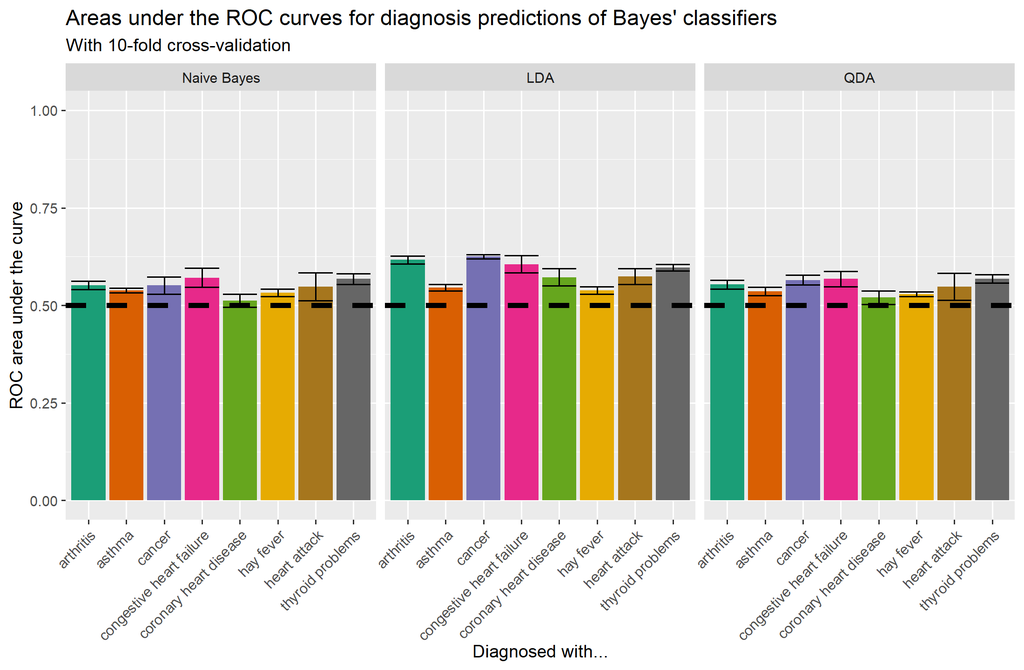

Figure 4: Areas under the receiver operator characteristic curves (ROC-AUCs) for 10-fold cross-validated predictions of diagnosis outcomes from nutrient intake predictors, separated by method of Bayes classification (naive Bayes, LDA, or QDA). The expected ROC-AUC of a random (uninformed by predictors) classifier, 0.5, is given by the dashed black line.

To determine if the models’ poor performances were in-part due to the presence of outliers in the nutrient intake predictor variables, we removed observations from the data containing outliers (i.e., values less than their variable’s 25th percentile$-1.5\mathrm{IQR}$ or greater than their variable’s 75th percentile$+1.5\mathrm{IQR}$) in any of the predictors and re-trained the models with this subset of the data. This endeavor did not produce a substantial improvement in performance: while most of the models experienced a slight increase in ROC-AUC, the metric’s values were still very near to 0.5 (Figure 5) and the ROC curves themselves were largely unchanged in shape, besides exhibiting more variation due to the greater effect of noise on the smaller sample sizes (Figure 6).

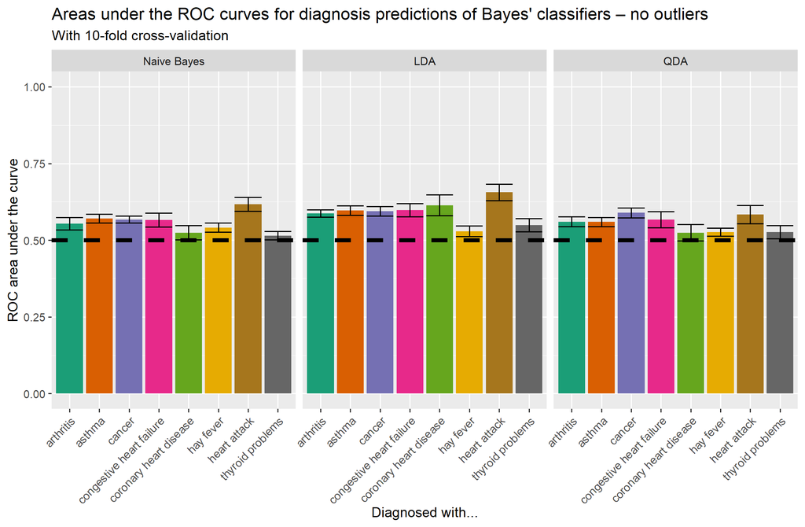

Figure 5: Areas under the receiver operator characteristic curves (ROC-AUCs) for 10-fold cross-validated predictions of diagnosis outcomes from nutrient intake predictors, using data from which observations with outliers in any predictors were removed, separated by method of Bayes classification (naive Bayes, LDA, or QDA). The expected ROC-AUC of a random (uninformed by predictors) classifier, 0.5, is given by the dashed black line.

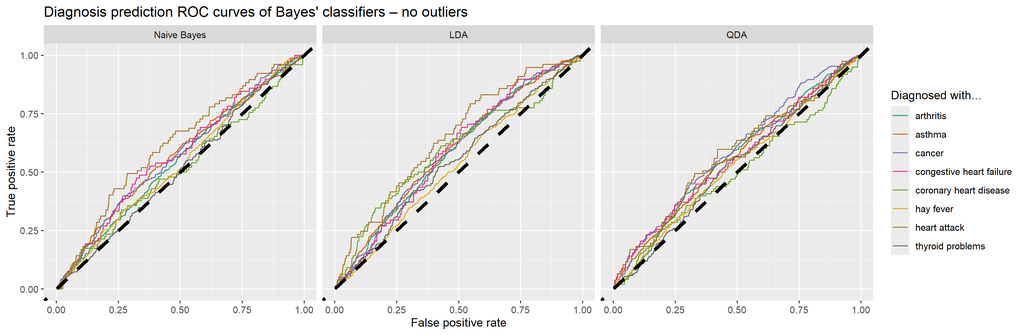

Figure 6: Receiver operator characteristic (ROC) curves for 10-fold cross-validated predictions of diagnosis outcomes from nutrient intake predictors, using data from which observations with outliers in any predictors were removed, separated by method of Bayes classification (naive Bayes, LDA, or QDA).

Overall, then, we can reasonably conclude that these Bayes classifier models are incapable of reliably predicting diagnoses of any condition from nutrient intake in this dataset.

The code for creating the above plots is reproduced below:

```r
# Plotting ####

## Outliers included ####

### Accuracy plots ####

classifiers <- c('Naive Bayes', 'LDA', 'QDA')

accuracies <- list(nb=nbAccuracies,
                   lda=ldaAccuracies,
                   qda=qdaAccuracies)

for (t in 1:length(classifiers)){
  accuracies[[t]] <- accuracies[[t]] |>
    mutate(Classifier=classifiers[t],.before=1)
}

ROC_AUCs <- bind_rows(accuracies) |>
  mutate(Classifier=factor(Classifier,levels=c('Naive Bayes','LDA','QDA'))) |>
  filter(.metric=='roc_auc') |>
  mutate(outcome=str_replace_all(outcome,'_',' '))

accuracies <- bind_rows(accuracies) |>
  mutate(Classifier=factor(Classifier,levels=c('Naive Bayes','LDA','QDA'))) |>
  filter(.metric=='accuracy') |>
  mutate(outcome=str_replace_all(outcome,'_',' ')) |>
  rowwise() |>
  mutate(mean=mean*100,std_err=std_err*100)

bayesPlot <- accuracies |>
  ggplot(aes(outcome,mean,fill=outcome))+
  facet_wrap(~Classifier)+
  geom_col(position='dodge')+
  geom_errorbar(aes(ymin = mean-std_err, ymax = mean+std_err), position = "dodge")+
  scale_fill_brewer(guide='none',palette = 'Dark2')+
  scale_y_continuous(limits=c(0,100))+
  labs(y='Prediction accuracy (%)',x='Diagnosed with...',title='Diagnosis prediction accuracy of Bayes\' classifiers', subtitle='With 10-fold cross-validation')+
  theme(axis.text.x=element_text(angle=45, vjust = 1, hjust=1))

if(plotsToWindow) bayesPlot


### ROC(-AUC) plots ####

nbROCs <- list()
for (w in 1:length(nbFits)){
  nbROCs[[w]] <- collect_predictions(nbFits[[w]]) |>
    roc_curve(truth=names(nbFits)[w],.pred_Yes) |>
    mutate(outcome=names(nbFits[w]),.before=1)
}
nbROCs <- bind_rows(nbROCs) |>
  mutate(Classifier='Naive Bayes')

ldaROCs <- list()
for (w in 1:length(ldaFits)){
  ldaROCs[[w]] <- collect_predictions(ldaFits[[w]]) |>
    roc_curve(truth=names(ldaFits)[w],.pred_Yes) |>
    mutate(outcome=names(ldaFits[w]),.before=1)
}
ldaROCs <- bind_rows(ldaROCs) |>
  mutate(Classifier='LDA')

qdaROCs <- list()
for (w in 1:length(qdaFits)){
  qdaROCs[[w]] <- collect_predictions(qdaFits[[w]]) |>
    roc_curve(truth=names(qdaFits)[w],.pred_Yes) |>
    mutate(outcome=names(qdaFits[w]),.before=1)
}
qdaROCs <- bind_rows(qdaROCs) |>
  mutate(Classifier='QDA')

ROCs <- bind_rows(list(nbROCs,ldaROCs,qdaROCs)) |>
  mutate(Classifier=factor(Classifier,levels=c('Naive Bayes','LDA','QDA'))) |>
  mutate(outcome=str_replace_all(outcome,'_',' '))

bayesROCPlot <- ROCs |>
  ggplot(aes(x=1-specificity, y=sensitivity, color=outcome))+
  facet_wrap(~Classifier)+
  geom_path()+
  geom_abline(lty=2,lwd=1.5)+
  scale_color_brewer(palette='Dark2',name="Diagnosed with...")+
  labs(x = 'False positive rate', y='True positive rate', title='Diagnosis prediction ROC curves of Bayes\' classifiers')

if(plotsToWindow) bayesROCPlot


ldaROCPlot <- ROCs |>
  filter(Classifier=='LDA') |>
  ggplot(aes(x=1-specificity, y=sensitivity, color=outcome))+
  facet_wrap(~outcome)+
  geom_path()+
  geom_abline(lty=2,lwd=1.5)+
  scale_color_brewer(palette='Dark2',guide = 'none')+
  labs(x = 'False positive rate', y='True positive rate', title='Diagnosis prediction ROC curves of LDA classifier')

if(plotsToWindow) ldaROCPlot


bayesROC_AUCPlot <- ROC_AUCs |>
  ggplot(aes(outcome,mean,fill=outcome))+
  facet_wrap(~Classifier)+
  geom_col(position='dodge')+
  geom_hline(yintercept=0.5,lty=2,lwd=1.5)+
  scale_y_continuous(limits=c(0,1))+
  geom_errorbar(aes(ymin = mean-std_err, ymax = mean+std_err), position = "dodge")+
  scale_fill_brewer(guide='none',palette = 'Dark2')+
  labs(y='ROC area under the curve',x='Diagnosed with...',title='Areas under the ROC curves for diagnosis predictions of Bayes\' classifiers', subtitle='With 10-fold cross-validation')+
  theme(axis.text.x=element_text(angle=45, vjust = 1, hjust=1))

if(plotsToWindow) bayesROC_AUCPlot




## Outliers removed ####

### Accuracy plots ####

accuracies_outliers <- list(nb=nbAccuracies_outliers,
                   lda=ldaAccuracies_outliers,
                   qda=qdaAccuracies_outliers)

for (t in 1:length(classifiers)){
  accuracies_outliers[[t]] <- accuracies_outliers[[t]] |>
    mutate(Classifier=classifiers[t],.before=1)
}

ROC_AUCs_outliers <- bind_rows(accuracies_outliers) |>
  mutate(Classifier=factor(Classifier,levels=c('Naive Bayes','LDA','QDA'))) |>
  filter(.metric=='roc_auc') |>
  mutate(outcome=str_replace_all(outcome,'_',' '))

accuracies_outliers <- bind_rows(accuracies_outliers) |>
  mutate(Classifier=factor(Classifier,levels=c('Naive Bayes','LDA','QDA'))) |>
  filter(.metric=='accuracy') |>
  mutate(outcome=str_replace_all(outcome,'_',' ')) |>
  rowwise() |>
  mutate(mean=mean*100,std_err=std_err*100)

bayesPlot_outliers <- accuracies_outliers |>
  ggplot(aes(outcome,mean,fill=outcome))+
  facet_wrap(~Classifier)+
  geom_col(position='dodge')+
  geom_errorbar(aes(ymin = mean-std_err, ymax = mean+std_err), position = "dodge")+
  scale_fill_brewer(guide='none',palette = 'Dark2')+
  scale_y_continuous(limits=c(0,100))+
  labs(y='Prediction accuracy (%)',x='Diagnosed with...',title='Diagnosis prediction accuracy of Bayes\' classifiers – no outliers', subtitle='With 10-fold cross-validation')+
  theme(axis.text.x=element_text(angle=45, vjust = 1, hjust=1))

if(plotsToWindow) bayesPlot_outliers


### ROC(-AUC) plots ####

nbROCs_outliers <- list()
for (w in 1:length(nbFits_outliers)){
  nbROCs_outliers[[w]] <- collect_predictions(nbFits_outliers[[w]]) |>
    roc_curve(truth=names(nbFits_outliers)[w],.pred_Yes) |>
    mutate(outcome=names(nbFits_outliers[w]),.before=1)
}
nbROCs_outliers <- bind_rows(nbROCs_outliers) |>
  mutate(Classifier='Naive Bayes')

ldaROCs_outliers <- list()
for (w in 1:length(ldaFits_outliers)){
  ldaROCs_outliers[[w]] <- collect_predictions(ldaFits_outliers[[w]]) |>
    roc_curve(truth=names(ldaFits_outliers)[w],.pred_Yes) |>
    mutate(outcome=names(ldaFits_outliers[w]),.before=1)
}
ldaROCs_outliers <- bind_rows(ldaROCs_outliers) |>
  mutate(Classifier='LDA')

qdaROCs_outliers <- list()
for (w in 1:length(qdaFits_outliers)){
  qdaROCs_outliers[[w]] <- collect_predictions(qdaFits_outliers[[w]]) |>
    roc_curve(truth=names(qdaFits_outliers)[w],.pred_Yes) |>
    mutate(outcome=names(qdaFits_outliers[w]),.before=1)
}
qdaROCs_outliers <- bind_rows(qdaROCs_outliers) |>
  mutate(Classifier='QDA')

ROCs_outliers <- bind_rows(list(nbROCs_outliers,ldaROCs_outliers,qdaROCs_outliers)) |>
  mutate(Classifier=factor(Classifier,levels=c('Naive Bayes','LDA','QDA'))) |>
  mutate(outcome=str_replace_all(outcome,'_',' '))

bayesROCPlot_outliers <- ROCs_outliers |>
  ggplot(aes(x=1-specificity, y=sensitivity, color=outcome))+
  facet_wrap(~Classifier)+
  geom_path()+
  geom_abline(lty=2,lwd=1.5)+
  scale_color_brewer(palette='Dark2',name="Diagnosed with...")+
  labs(x = 'False positive rate', y='True positive rate', title='Diagnosis prediction ROC curves of Bayes\' classifiers – no outliers')

if(plotsToWindow) bayesROCPlot_outliers


ldaROCPlot_outliers <- ROCs_outliers |>
  filter(Classifier=='LDA') |>
  ggplot(aes(x=1-specificity, y=sensitivity, color=outcome))+
  facet_wrap(~outcome)+
  geom_path()+
  geom_abline(lty=2,lwd=1.5)+
  scale_color_brewer(palette='Dark2',guide = 'none')+
  labs(x = 'False positive rate', y='True positive rate', title='Diagnosis prediction ROC curves of LDA classifier – no outliers')

if(plotsToWindow) ldaROCPlot_outliers


bayesROC_AUCPlot_outliers <- ROC_AUCs_outliers |>
  ggplot(aes(outcome,mean,fill=outcome))+
  facet_wrap(~Classifier)+
  geom_col(position='dodge')+
  geom_hline(yintercept=0.5,lty=2,lwd=1.5)+
  scale_y_continuous(limits=c(0,1))+
  geom_errorbar(aes(ymin = mean-std_err, ymax = mean+std_err), position = "dodge")+
  scale_fill_brewer(guide='none',palette = 'Dark2')+
  labs(y='ROC area under the curve',x='Diagnosed with...',title='Areas under the ROC curves for diagnosis predictions of Bayes\' classifiers – no outliers', subtitle='With 10-fold cross-validation')+
  theme(axis.text.x=element_text(angle=45, vjust = 1, hjust=1))

if(plotsToWindow) bayesROC_AUCPlot_outliers




# Writing plots to file ####

if (plotsToFile){
  figs <- c('bayesPlot',
            'bayesPlot_outliers',
            'bayesROC_AUCPlot',
            'bayesROC_AUCPlot_outliers',
            'bayesROCPlot',
            'bayesROCPlot_outliers',
            'ldaROCPlot',
            'ldaROCPlot_outliers')

  fignames <- c('bayes_classifiers_accuracy_comparison',
                'bayes_classifiers_accuracy_comparison_no_outliers',
                'bayes_classifiers_ROC-AUC_comparison',
                'bayes_classifiers_ROC-AUC_comparison_no_outliers',
                'bayes_classifiers_ROC_curves_comparison',
                'bayes_classifiers_ROC_curves_comparison_no_outliers',
                'LDA_classifier_ROC_curves_comparison',
                'LDA_classifier_ROC_curves_comparison_no_outliers')

  folderpath <- paste(getwd(),'/figures/bayes/', sep='')
  dir.create(folderpath)

  widths <- c(rep(2200,4),rep(4400*.75,2), rep(1800,2))
  heights <- c(rep(1440,4), rep(1440*.75,2),rep(1600,2))
  ress <- c(rep(250,8))

  for (i in 1:length(figs)) {
    fig <- figs[i]
    png(filename=paste(folderpath, fignames[i], '.png', sep=''), width=widths[i], height=heights[i], res=ress[i])
    print(get(fig))
    dev.off()
  }
}
```

### 4.2 Decision tree and random forest – Romy

Here are the accuracy and AUC of decision trees on the eight response variables of interest.

```r
## Plotting the accuracy and AUC
### Accuracy
accuracy_df <- data.frame(
  Model = rep(c('Asthma','Hay Fever','Arthritis','Congestive Heart Failure','Coronary Heart Disease','Heart Attack','Thyroid Problems','Cancer'), each = 2),
  Accuracy = c(asthma_train_accuracy$.estimate, asthma_test_accuracy$.estimate, hay_fever_train_accuracy$.estimate, hay_fever_test_accuracy$.estimate,
               arthritis_train_accuracy$.estimate, arthritis_test_accuracy$.estimate, congestive_train_accuracy$.estimate, congestive_test_accuracy$.estimate,
               coronary_train_accuracy$.estimate, coronary_test_accuracy$.estimate, heart_attack_train_accuracy$.estimate, heart_attack_test_accuracy$.estimate,
               thyroid_train_accuracy$.estimate, thyroid_test_accuracy$.estimate, cancer_train_accuracy$.estimate, cancer_test_accuracy$.estimate),
  Set = rep(c('Training','Testing'), times = 8)
)

ggplot(accuracy_df, aes(x = Model, y = Accuracy, fill = Set)) +
  geom_bar(stat = "identity", position = "dodge") +
  labs(title = "Training vs Testing Accuracy for Each Model",
       x = "Model",
       y = "Accuracy") +
  theme_minimal() +
  theme(axis.text.x = element_text(angle = 45, hjust = 1),
        text = element_text(size = 20))

### AUC
auc_df <- data.frame(
  Model = c('Asthma','Hay Fever','Arthritis','Congestive Heart Failure','Coronary Heart Disease','Heart Attack','Thyroid Problems','Cancer'),
  AUC = c(asthma_auc$.estimate, hay_fever_auc$.estimate, arthritis_auc$.estimate, congestive_auc$.estimate,
          coronary_auc$.estimate, heart_attack_auc$.estimate, thyroid_auc$.estimate, cancer_auc$.estimate)
)

ggplot(auc_df, aes(x = Model, y = AUC)) +
  geom_bar(stat = "identity", position = "dodge") +
  labs(title = "AUC for Each Model",
       x = "Model",
       y = "AUC") +
  theme_minimal() +
  theme(axis.text.x = element_text(angle = 45, hjust = 1),
        text = element_text(size = 20)) +
  ylim(0,1) +
  geom_hline(yintercept = 0.5, linetype = 'dashed', color = 'red', linewidth = 1.2)
```

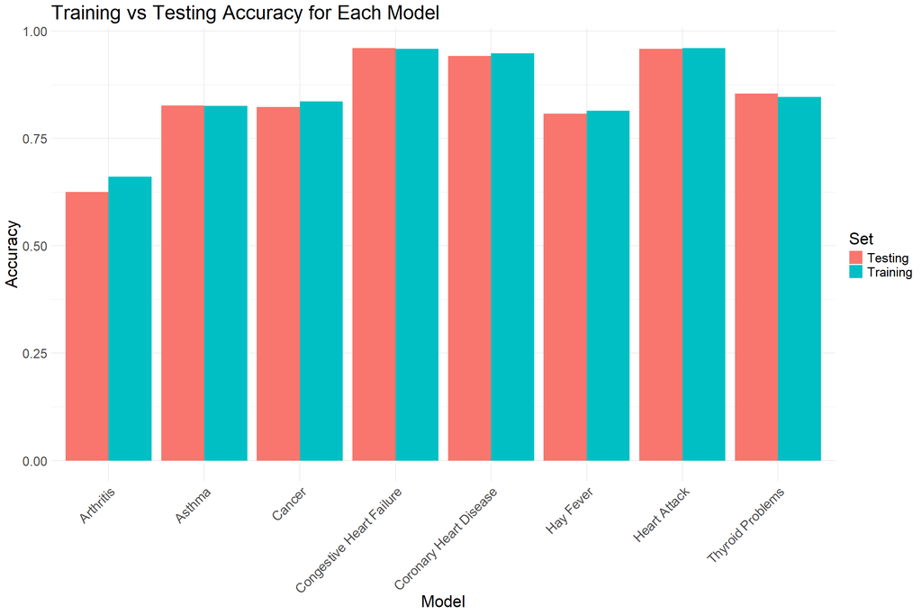

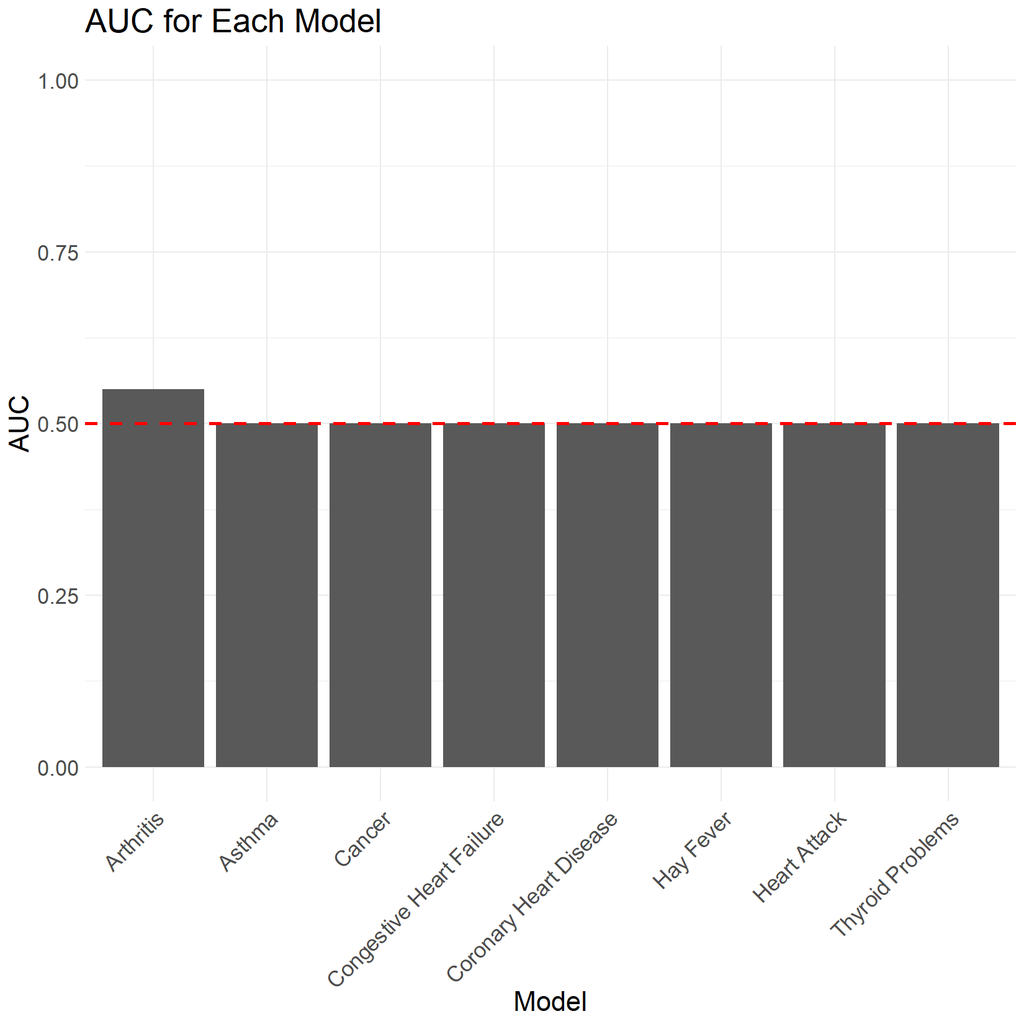

The model produces good accuracy but very poor AUC because it is putting everything into the same category. Next is random forest:

```r
## Plotting the accuracy and AUC
### Accuracy
forest_accuracy_df <- data.frame(
  Model = rep(c('Asthma','Hay Fever','Arthritis','Congestive Heart Failure','Coronary Heart Disease','Heart Attack','Thyroid Problems','Cancer'), each = 2),
  Accuracy = c(asthma_forest_train_accuracy$.estimate, asthma_forest_test_accuracy$.estimate, hay_fever_forest_train_accuracy$.estimate, hay_fever_forest_test_accuracy$.estimate,
               arthritis_forest_train_accuracy$.estimate, arthritis_forest_test_accuracy$.estimate, congestive_forest_train_accuracy$.estimate, congestive_forest_test_accuracy$.estimate,
               coronary_forest_train_accuracy$.estimate, coronary_forest_test_accuracy$.estimate, heart_attack_forest_train_accuracy$.estimate, heart_attack_forest_test_accuracy$.estimate,
               thyroid_forest_train_accuracy$.estimate, thyroid_forest_test_accuracy$.estimate, cancer_forest_train_accuracy$.estimate, cancer_forest_test_accuracy$.estimate),
  Set = rep(c('Training','Testing'), times = 8)
)

ggplot(forest_accuracy_df, aes(x = Model, y = Accuracy, fill = Set)) +
  geom_bar(stat = "identity", position = "dodge") +
  labs(title = "Training vs Testing Accuracy for Each Model",
       x = "Model",
       y = "Accuracy") +
  theme_minimal() +
  theme(axis.text.x = element_text(angle = 45, hjust = 1),
        text = element_text(size = 20))

### AUC
forest_auc_df <- data.frame(
  Model = c('Asthma','Hay Fever','Arthritis','Congestive Heart Failure','Coronary Heart Disease','Heart Attack','Thyroid Problems','Cancer'),
  AUC = c(arthritis_auc$.estimate, hay_fever_auc$.estimate, arthritis_auc$.estimate, congestive_auc$.estimate,
          coronary_auc$.estimate, heart_attack_auc$.estimate, thyroid_auc$.estimate, cancer_auc$.estimate)
)

ggplot(forest_auc_df, aes(x = Model, y = AUC)) +
  geom_bar(stat = "identity", position = "dodge") +
  labs(title = "AUC for Each Model",
       x = "Model",
       y = "AUC") +
  theme_minimal() +
  theme(axis.text.x = element_text(angle = 45, hjust = 1),
        text = element_text(size = 20)) +
  ylim(0,1) +
  geom_hline(yintercept = 0.5, linetype = 'dashed', color = 'red', linewidth = 1.2)

vip(asthma_forest_fit)
```

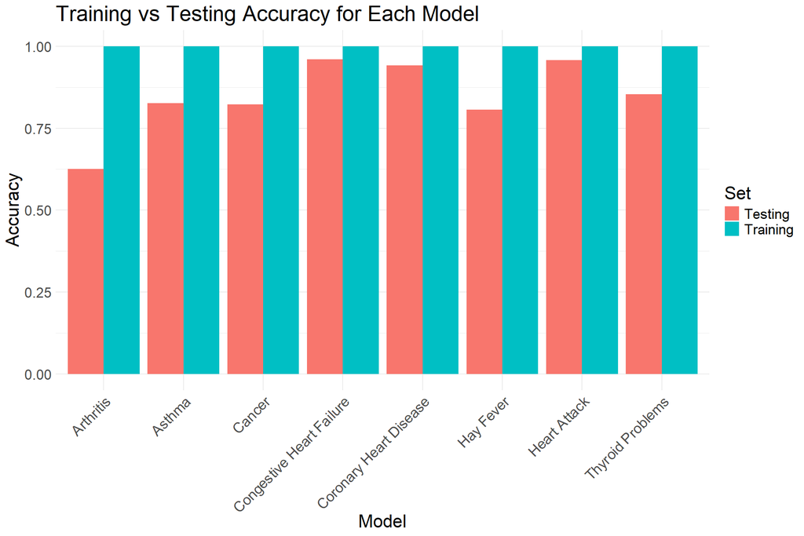

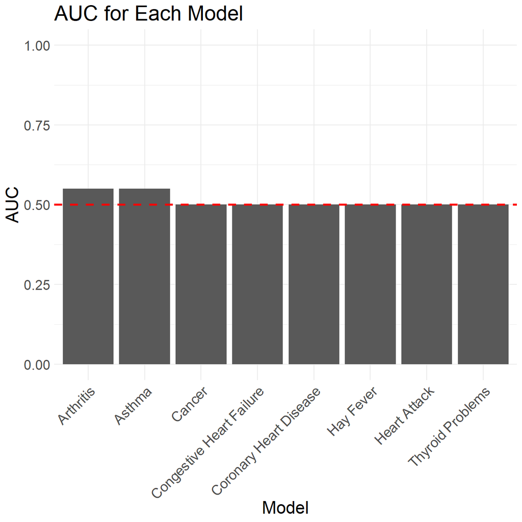

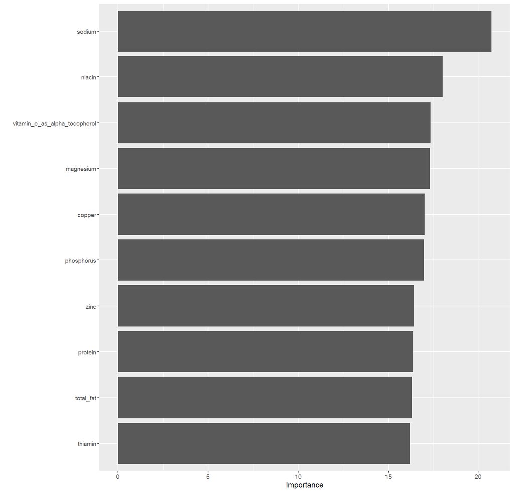

Finally, I tried to tune the value of `mtry` for the best AUC value.

```r
ggplot(tuning_metrics, aes(x = mtry, y = mean)) +
  geom_point() +
  geom_errorbar(aes(ymin = mean - std_err, ymax = mean + std_err)) +
  labs(title = 'Random Forest Tuning Results', x = 'mtry', y = 'AUC') +
  theme_minimal() +
  theme(axis.title = element_text(size = 15), plot.title = element_text(size = 22))
  ylim(0.5,0.7)
```

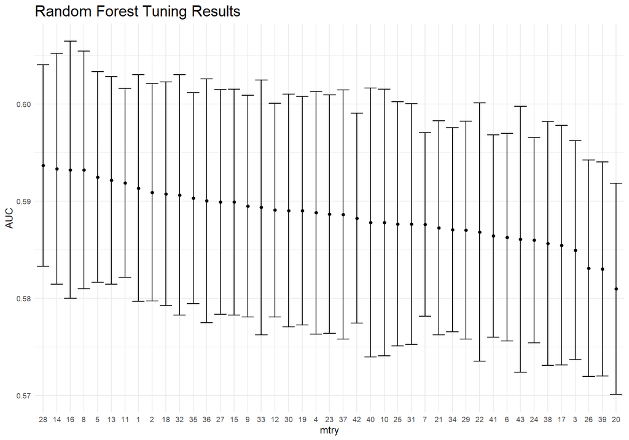

Even the best `mtry` value still gives an AUC of below 0.6. In conclusion, decision trees and random forest fail to predict our response variables nicely.

### 4.3 Neural network – Alissa

```python
# VERTICAL WHISKER PLOT FOR AUC SCORES
plt.figure(figsize=(12, 6))
sns.boxplot(data=pd.DataFrame(auc_scores), orient="v", palette="Set2")
plt.xticks(rotation=20, fontsize=8)
plt.ylabel("AUC Score")
plt.title("AUC Scores for Each Response Variable")
plt.show()

# ROC CURVES FOR EACH RESPONSE VARIABLE
fig, axes = plt.subplots(2, 4, figsize=(16, 8))
fig.suptitle("ROC Curves for Each Response Variable", fontsize=14)

for ax, (response_name, (fprs, tprs)) in zip(axes.flatten(), roc_curves.items()):
    for fold in range(len(fprs)):
        ax.plot(fprs[fold], tprs[fold], lw=2, alpha=0.5, label=f"Fold {fold+1}")
    ax.plot([0, 1], [0, 1], linestyle="--", lw=2, color="r", label="Random Guess")
    ax.set_xlabel("False Positive Rate")
    ax.set_ylabel("True Positive Rate")
    ax.set_title(response_name)
plt.tight_layout(rect=[0, 0, 1, 0.96])
plt.show()

# CONFUSION MATRICES FOR ALL RESPONSE VARIABLES
fig, axes = plt.subplots(2, 4, figsize=(16, 8))
fig.suptitle("Confusion Matrices for Each Response Variable", fontsize=14)

for ax, (response_name, conf_matrices) in zip(axes.flatten(), train_conf_matrices.items()):
    avg_conf_matrix = np.mean(conf_matrices, axis=0)
    avg_conf_matrix = np.round(avg_conf_matrix).astype(int)
    sns.heatmap(avg_conf_matrix, annot=True, fmt="d", cmap="Blues",
                xticklabels=["Class 0", "Class 1"], yticklabels=["Class 0", "Class 1"],
                ax=ax)
    ax.set_title(response_name)
    ax.set_xlabel("Predicted")
    ax.set_ylabel("True")

plt.tight_layout(rect=[0, 0, 1, 0.96])
plt.show()

# PREDICTION ACCURACY
plt.figure(figsize=(12, 6))
names = list(average_train_acc.keys())
train_acc_values = [average_train_acc[name] for name in names]
test_acc_values = [average_test_acc[name] for name in names]
x = range(len(names))
width = 0.4
plt.bar(x, train_acc_values, width=width, label='Train Accuracy', color='green', alpha=0.6)
plt.bar([p + width for p in x], test_acc_values, width=width, label='Test Accuracy', color='red', alpha=0.6)
plt.xticks([p + width/2 for p in x], names, rotation=20, fontsize=8)
plt.ylabel("Accuracy")
plt.title("Average Prediction Accuracy across 10-Fold CV for Each Response Variable")
plt.legend()
plt.yticks(fontsize=10, rotation=45)
plt.show()
```

**Neural Network Plots**

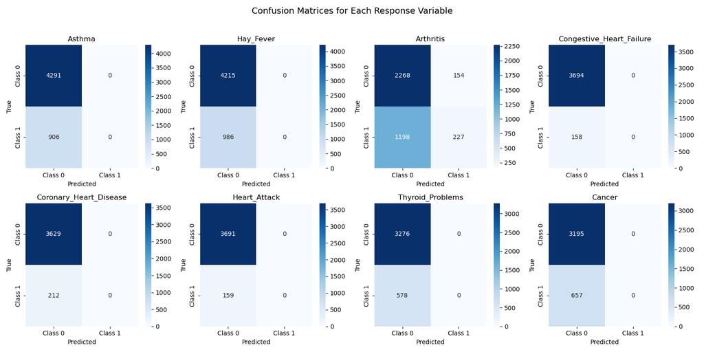

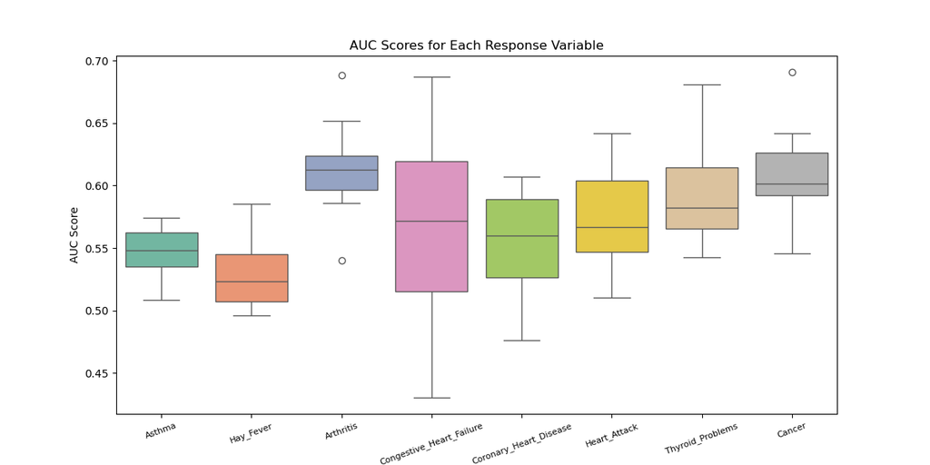

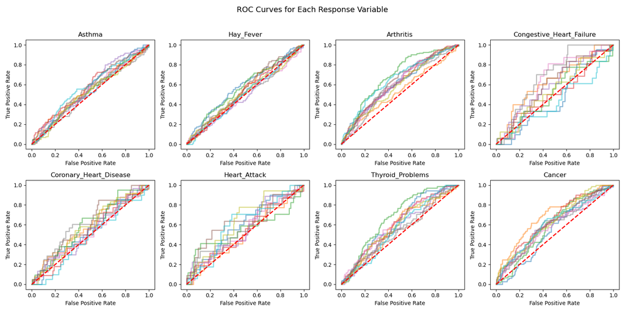

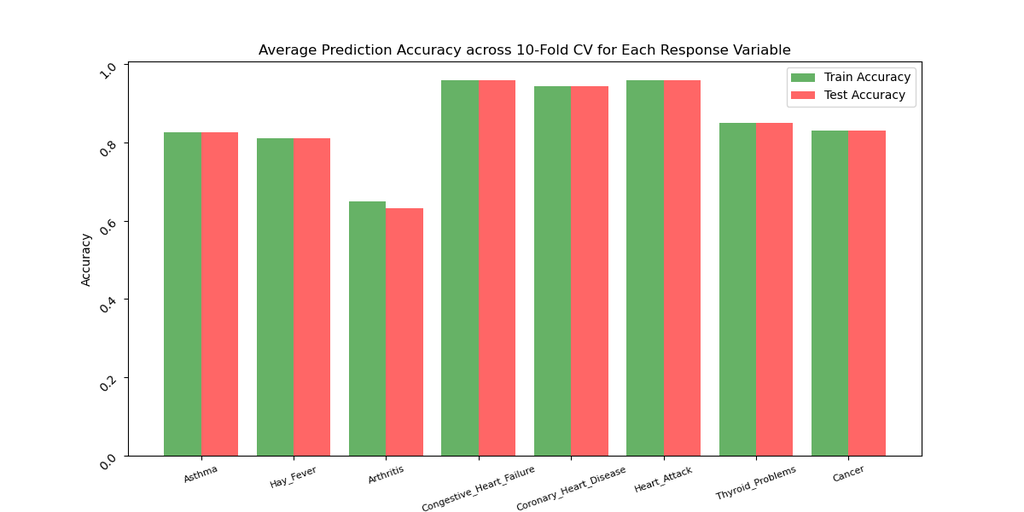

**Neural Network with Undersampling Plots**

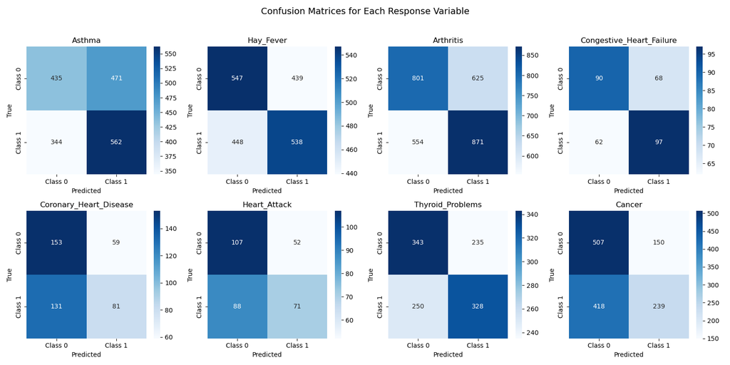

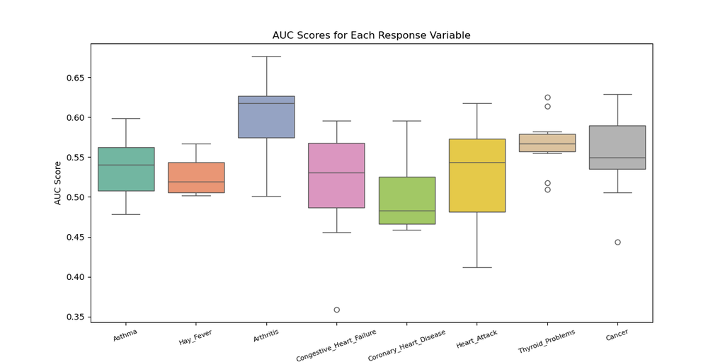

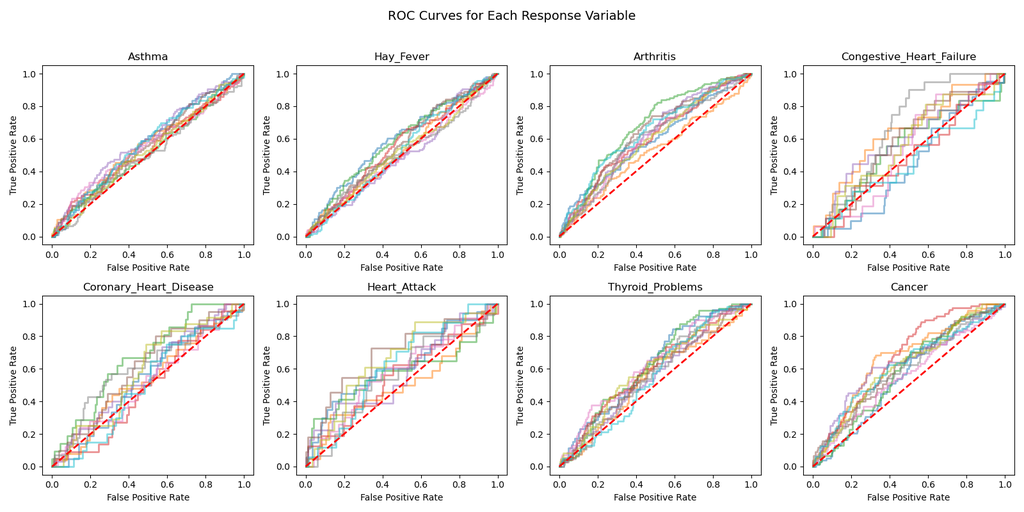

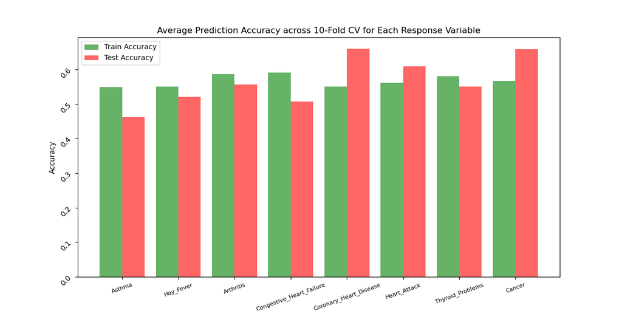

## 5 Conclusions

(Written by Cameron.)

While we would prefer to have developed powerful models that could be reliably used to predict whether a person is likely to have a medical condition from their nutrient intakes, our models are clearly insufficient to succeed at such a task, regardless of whether we implement outlier removal, hyperparameter tuning, or undersampling to address this. There are, of course, numerous explanations for why this may be. It is possible that the relationship between nutrient intake and the condition statuses we examined is weak enough that the effects cannot be reliably determined from this dataset in which outcome values are so heavily weighted towards “No”; or that daily nutrient intake, even when averaged across two days, is subject to far too much variance for a relationship to be captured from only two days’ of measurements; or that the dataset lacks some predictors which may dominate the effect of nutrient intake on these conditions. What seems much more likely, however, is the far simpler explanation: there simply isn’t a strong enough relationship for reliable classification to begin with!

## 6 References

National Center for Health Statistics. National Health and Nutrition Examination Survey, August 2021-August 2023. Public-use data file and documentation. https://wwwn.cdc.gov/nchs/nhanes/continuousnhanes/default.aspx?Cycle=2021-2023. 2025.

## 7 Appendix – dataset glimpses

Glimpses of the two NHANES datasets used, the dietary data and the “Medical Conditions” subset of the questionnaire data, are provided in Listing 1 and Listing 2 below:

Listing 1: Sample glimpses of the Nutrition NHANES dataset

```r
glimpse(Nutrition_D1)
```

```
Rows: 8,860
Columns: 168
$ SEQN     <dbl> 130378, 130379, 130380, 130381, 130382, 130386, 130387, 13038…
$ WTDRD1   <dbl> 61366.56, 34638.06, 84728.26, 61737.13, 75846.75, 82013.37, 2…
$ WTDR2D   <dbl> 70554.22, 36505.47, 103979.19, 75009.22, 172361.85, 73251.22,…
$ DR1DRSTZ <dbl> 1, 1, 1, 1, 1, 1, 1, 5, 1, 1, 5, 1, 5, 1, 5, 5, 1, 1, 1, 1, 1…
$ DR1EXMER <dbl> 73, 73, 73, 91, 73, 90, 5, NA, 89, 65, NA, 90, NA, 90, NA, NA…
$ DRABF    <dbl> 2, 2, 2, 2, 2, 2, 2, NA, 2, 2, NA, 2, NA, 2, NA, NA, 2, 2, 2,…
$ DRDINT   <dbl> 2, 2, 2, 2, 2, 2, 2, NA, 2, 1, NA, 2, NA, 2, NA, NA, 2, 1, 1,…
$ DR1DBIH  <dbl> 40, 19, 16, 23, 27, 18, 31, NA, 27, 23, NA, 19, NA, 47, NA, N…
$ DR1DAY   <dbl> 4, 4, 4, 5, 6, 6, 3, NA, 1, 2, NA, 6, NA, 5, NA, NA, 1, 4, 4,…
$ DR1LANG  <dbl> 1, 1, 1, 1, 1, 1, 1, NA, 1, 1, NA, 1, NA, 1, NA, NA, 1, 2, 1,…
$ DR1MRESP <dbl> 1, 1, 1, 2, 2, 1, 1, NA, 1, 1, NA, 1, NA, 1, NA, NA, 1, 1, 1,…
$ DR1HELP  <dbl> 12, 12, 12, 1, 12, 12, 12, NA, 12, 12, NA, 12, NA, 12, NA, NA…
$ DBQ095Z  <dbl> 4, 1, 1, 4, 4, 4, 1, NA, 1, 1, NA, 1, NA, 1, NA, NA, 1, 1, 4,…
```

[output cut: 155 more lines]

Listing 2: Sample glimpses of the Medical Conditions NHANES dataset

```r
glimpse(Medical_Conditions)
```

```
Rows: 11,744
Columns: 35
$ SEQN    <dbl> 130378, 130379, 130380, 130381, 130382, 130383, 130384, 130385…
$ MCQ010  <dbl> 2, 2, 2, 2, 2, 2, 2, 1, 2, 2, 2, 2, 2, 2, 2, 1, 2, 2, 2, 2, 2,…
$ MCQ035  <dbl> NA, NA, NA, NA, NA, NA, NA, 2, NA, NA, NA, NA, NA, NA, NA, 2, …
$ MCQ040  <dbl> NA, NA, NA, NA, NA, NA, NA, NA, NA, NA, NA, NA, NA, NA, NA, NA…
$ MCQ050  <dbl> NA, NA, NA, NA, NA, NA, NA, NA, NA, NA, NA, NA, NA, NA, NA, NA…
$ AGQ030  <dbl> 2, 2, 2, 1, 2, 2, 2, 2, 2, 2, 1, 2, 2, 2, 2, 1, 2, 2, 2, 2, 2,…
$ MCQ053  <dbl> 2, 2, 2, 2, 2, 2, 2, 2, 2, 2, 1, 2, 2, 2, 2, 2, 2, 2, 2, 2, 2,…
$ MCQ149  <dbl> NA, NA, NA, NA, NA, NA, NA, NA, NA, NA, NA, NA, NA, NA, NA, NA…
$ MCQ160A <dbl> 1, 2, 2, NA, NA, NA, 2, 2, 2, 2, 2, 2, 2, 2, 1, 2, 2, 1, 2, 2,…
$ MCQ195  <dbl> 2, NA, NA, NA, NA, NA, NA, NA, NA, NA, NA, NA, NA, NA, 4, NA, …
$ MCQ160B <dbl> 2, 2, 2, NA, NA, NA, 2, 2, 2, 2, 2, 2, 2, 2, 2, 2, 2, 2, 2, 1,…
$ MCQ160C <dbl> 2, 2, 2, NA, NA, NA, 2, 2, 2, 2, 2, 2, 2, 2, 2, 2, 2, 2, 2, 2,…
$ MCQ160D <dbl> 2, 2, 2, NA, NA, NA, 2, 2, 2, 2, 2, 2, 2, 2, 2, 2, 2, 2, 2, 2,…
```

[output cut: 22 more lines]